# Segundo Exercício

### Aluno: Matheus Jun Ota

### RA: 138889

> Fazer uma simulação com trace de dados como ordenador de eventos (chegada de pacote), plotar gráfico tamanho médio da fila x utilização. Entregar relatório com código fonte e gráfico e explicação sobre o simulador e resultados encontrados. Os registros dos arquivos contém a hora de chegada do pacotes em segundos e o tamanho do pacote.

Primeiramente, iremos criar uma classe para ler o arquivo com os instantes de chegada e o tamanho de cada pacote. Além disso, essa classe irá também computar o intervalo entre chegada de pacotes, a média de pacotes que chegam por segundo, e o tamanho médio dos pacotes.

```python
import numpy as np
import pandas as pd
import seaborn as sns
import itertools
import matplotlib.pyplot as plt
import math
import random
import statistics

class QueueFileReader():
    def __init__(self):
        file = open("data.txt")

        # read from file
        arrivalTimes = []
        self.packetsSizes = []
        self.packetsSizesIdx = 0

        for line in file:
            lineItems = line.split()

            arrivalTimes.append(float(lineItems[0]))
            self.packetsSizes.append(int(lineItems[1]))

        # compute arrival intervals from the arrival times
        self.arrivalIntervals = [arrivalTimes[0]]
        self.arrivalIntervalsIdx = 0
        for i in range(1, len(arrivalTimes)):
            self.arrivalIntervals.append(arrivalTimes[i] - arrivalTimes[i - 1])

        # estimate arrival rate and mean packet size
        self.arrivalRate = 1./(sum(self.arrivalIntervals) / len(self.arrivalIntervals))
        self.meanPacketSize = sum(self.packetsSizes) / len(self.packetsSizes)

    def getNextArrivalInterval(self):
        if self.arrivalIntervalsIdx >= len(self.arrivalIntervals):
            return None

        self.arrivalIntervalsIdx += 1
        return self.arrivalIntervals[self.arrivalIntervalsIdx - 1]

    def reset(self):
        self.arrivalIntervalsIdx = 0
        self.packetsSizesIdx = 0
```

Note que, por enquanto, nós só temos o tamanho do pacote, mas nós precisamos estimar o tempo de serviço. Seja $\alpha$ o tempo necessário pelo servidor para processar 1 bit. Assim $\alpha * \mathbf{meanPacketSize}$ nos dá o tempo médio necessário para processar cada pacote. Além disso, defina $\beta = 1/\alpha$, então $\beta * 1/\mathbf{meanPacketSize}$ indica o número de pacotes servidos por segundo. Temos então o seguinte código para o método **getNextServiceTime**.

```python
class QueueFileReader(QueueFileReader):
    def setBeta(self, beta):
        self.alpha = 1./beta

    def getNextServiceTime(self):
        if self.packetsSizesIdx >= len(self.packetsSizes):
            return None

        self.packetsSizesIdx += 1
        return self.alpha * self.packetsSizes[self.packetsSizesIdx - 1]
```

Outra conclusão do raciocínio acima, é que podemos utilizar a fórmula $\beta * 1/\mathbf{meanPacketSize}$ para entender como devemos variar $\beta$ para plotar o gráfico de tamanho médio da fila por utilização. Seja $\lambda$ a taxa de chegada de pacotes, isto é, $\lambda = \mathbf{arrivalRate}$, e $\mu$ a taxa de serviço, isto é, $\mu = \beta * 1/\mathbf{meanPacketSize}$, queremos que encontrar $\alpha$ tal que:

$$\lambda < \mu = \beta * 1/\mathbf{meanPacketSize} \implies \lambda * \mathbf{meanPacketSize} < \beta$$

```python
queueFileReader = QueueFileReader()
print("lambda: " + str(queueFileReader.arrivalRate))
print("beta lower bound: " + str(queueFileReader.arrivalRate * queueFileReader.meanPacketSize))
```

```
lambda: 1848.1340423597308
beta lower bound: 1236271.906526219
```

E portanto, vamos variar $beta$ de $1236270$ a $10^{\ 9}$.

Agora que temos a classe **QueueFileReader**, nós iremos utilizar a mesma classe **Queue** do Primeiro Exercício mas obtendo os intervalos de chegada e de serviço com os métodos **getNextArrivalInterval** e **getNextServiceTime**.

```python
class Queue():
    def __init__(self, queueFileReader):
        self.usersInQueue = 0
        self.currTime = 0
        self.queueFileReader = queueFileReader
        self.arrivalTime = self.queueFileReader.getNextArrivalInterval()
        self.departureTime = float("inf")
        self.totalQ = 0

    def getRandomTime(self, param):
        return random.expovariate(param)

    def goToNextEvent(self):
        if self.arrivalTime < self.departureTime:
            self.totalQ += self.usersInQueue * (self.arrivalTime - self.currTime)
            self.currTime = self.arrivalTime
            self.handleArrivalEvent()
        else:
            self.totalQ += self.usersInQueue * (self.departureTime - self.currTime)
            self.currTime = self.departureTime
            self.handleDepartureEvent()

    def handleArrivalEvent(self):
        self.usersInQueue += 1

        if self.usersInQueue <= 1:
            self.departureTime = self.currTime + self.queueFileReader.getNextServiceTime()

        self.arrivalTime = self.currTime + self.queueFileReader.getNextArrivalInterval()

    def handleDepartureEvent(self):
        self.usersInQueue -= 1

        if self.usersInQueue > 0:
            self.departureTime = self.currTime + self.queueFileReader.getNextServiceTime()
        else:
            self.departureTime = float("inf")

    def getMeanQueueSize(self):
        if self.currTime == 0:
            return 0
        else:
            return self.totalQ / self.currTime
```

Além de alterar o modo como obtemos o próximo tempo de chegada e de saída de cada pacote. Nós também adicionamos uma variável **totalQ** que é utilizada para calcular o tamanho médio da fila. Para entender a maneira que estamos incrementando a variável **totalQ** é preciso antes entender como ela é definida. Seja $Q(t)$ uma função que retorna o tamanho da fila no tempo $t$, e seja $T$ o tempo total de simulação. Defina então **totalQ** como sendo $\int_{t = 0}^{T} Q(t)$. Note então que podemos calcular o tamanho médio $q$ da fila através da fórmula:

$q = \frac{1}{T} \int_{t = 0}^{T} Q(t)$

que é exatamente o que é feito no código.

Agora vamos plotar o gráfico da mesma maneira que fizemos no Primeiro Exercício, com a diferença de que nesse caso só executaremos uma simulação, que é correspondente ao trace do arquivo. Além disso, note que a variação de β não é feita de maneira linear pois β não é linear na utilização (eixo x do gráfico).

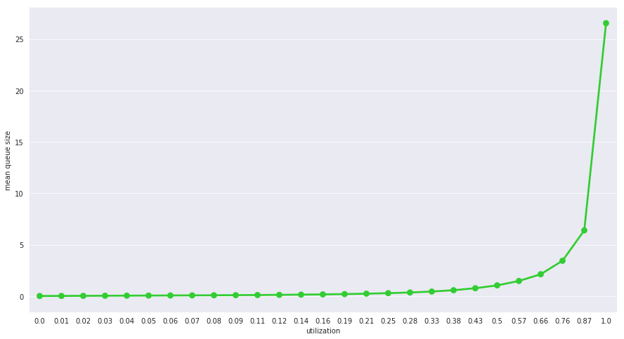

```python
means = []
utilization = []

# we change the arrival rate to change the utilization
beta = 1236270
while beta <= 10**9:
    serviceRate = beta * 1./(queueFileReader.meanPacketSize)

    queueFileReader.reset()
    queueFileReader.setBeta(beta)

    q = Queue(queueFileReader)

    for _ in range(10000):
        q.goToNextEvent()

    utilization.append(round(queueFileReader.arrivalRate / serviceRate, 2))
    means.append(q.getMeanQueueSize())

    beta *= 1.15

# create a pandas dataframe for the collected data
aux = {}
aux["utilization"] = utilization
aux["mean queue size"] = means
df = pd.DataFrame(aux)

# configure some plotting properties
sns.set_style("darkgrid")
sns.set_palette("hls")
plt.rcParams['figure.figsize'] = [15, 8]

# plot the means using seaborn
ax = sns.pointplot(x="utilization", y="mean queue size", data=df, color="limegreen", ci = 95)

plt.show()
```

E portanto, o gráfico obtido foi condizente com o esperado.